# 511-2015-10-05-evodevo

2015-10-05 15:55:31

## Today's Topics

- The evolution and development of the nervous system

## Ontogenesis and phylogenesis

- Ontogenesis
  - Development within lifetimes, history of individuals
- Phylogenesis
  - Change across lifestimes, history of species

## Ontogeny does not recapitulate phylogeny (Haeckel), but…

[figure not shown]

https://upload.wikimedia.org/wikipedia/commons/thumb/0/08/Haeckel_drawings.jpg/350px-Haeckel_drawings.jpg

## Complex multicellular life emerged "recently"

[figure not shown]

http://www.zo.utexas.edu/faculty/sjasper/images/26.2.gif

## Time scales

[figure not shown]

http://www.indiana.edu/~geol105b/images/gaia_chapter_6/time_scale.gif

## Evolution alters developmental programs

## Nervous system architectures

[figure not shown]

http://sites.sinauer.com/animalphys3e/boxex/AnPhys3e-BoxEx-15-01-0.jpg

## An animal with a nerve "net"

[video not shown]

## How nervous systems differ

- Body symmetry
  - radial
  - bilateral
- Segmentation
- Cephalization
- Encasement in bone (vertebrates)
- Centralized vs. distributed function

## Cephalopods have "intelligent arms"

[interactive chart not shown]

## Biological imperatives

- Ingestion
- Defense
- Reproduction

## Information processing schematic

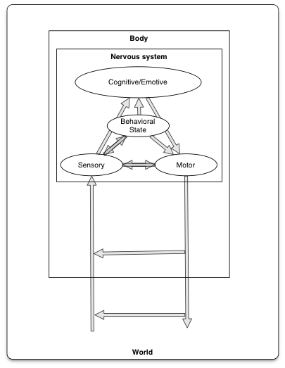

## Information processing universals

- Sense/detect
  - Sensors
- Analyze, evaluate, decide
- Act
  - Effectors
  - e.g., approach/avoid, manipulate, signal

## Sensors

- Specialize by information source/type
- Specialize by target location
  - Interoceptive
  - Exteroceptive

## Analysis, evaluation, decision

- Current state
  - World
  - Organism
- Current goals
- Past state(s)

## Effectors

- Move body
- Send signals
- Change physiological state

## Evolutionary trends in cortical size

[figure not shown]

(Hofman 2014)

## Evolutionary trends in cortical size

| Structural measure | Non-human comparison | Human |
| --- | --- | --- |
| Cortical gray matter %/tot brain vol | insectivores 25% | 50% |
| Cortical gray + white | mice 40% | 80% |
| Cerebellar mass | primates, mammals 10-15% | 10-15% |

## Evolutionary trends in cortical size

[figure not shown]

[(Rakic 2009)](http://dx.doi.org/10.1038/nrn2719)

## Evolutionary trends in primate brain size

[figure not shown]

[(Hofman 2014)](http://journal.frontiersin.org/article/10.3389/fnana.2014.00015/full)

## Human brains have

- Significant "folding"
- Dense interconnections
- Large "association" areas

## How did the system get this way?

## Insemination

- 3-4 days before or up to 1-2 days after…
  - Ovulation

## Fertilization

- Within ~ 24 hrs of ovulation

## Implantation

- ~ 6 days after fertilization

## In the beginning

[video not shown]

## Early embryogenesis

[video not shown]

## Formation of neural tube (neurulation)

- Ectoderm, mesoderm, endoderm
- ~18-26 days
- Failures of neural tube closure
  - Spina bifida
  - Anencephaly
- Neural tube becomes
  - Ventricles
  - Central canal of spinal cord

## Neurogenesis and gliogenesis

- Stem cells along ventricles
- Symmetric cell division
- Asymmetric cell division

## Radial glia

[figure not shown]

## Cell migration

[figure not shown]

## Radial unit hypothesis

[figure not shown]

[(Rakic 2009)](http://dx.doi.org/10.1038/nrn2719)

## Migration

[video not shown]

## Migration

[video not shown]

## Glial migration

[figure not shown]

http://physrev.physiology.org/content/81/2/871

## Axon growth cone

[video not shown]

## Axons follow

- Chemoattractants
  - e.g., Nerve Growth Factor (NGF)
- Chemorepellents
- Receptors in growth cone detect chemical gradients

## Differentiation

- Neuron vs. glial cell
- Cell type
- NTs released
- Where to connect

## Differential gene expression

[figure not shown]

[[johnson2009functional]](http://dx.doi.org/10.1016/j.neuron.2009.03.027)

## Prefrontal vs. Other Ctx

[figure not shown]

[[johnson2009functional]](http://dx.doi.org/10.1016/j.neuron.2009.03.027)

## Synaptogenesis

[figure not shown]

## Postnatal patterns of synaptogenesis

[figure not shown]

## Proliferation, pruning

- Early proliferation
- Later pruning
- Rates, peaks differ by area

## Apoptosis

- 20-80%, varies by area
- Spinal cord >> cortex

## Apoptosis and cortical expansion

[figure not shown]

[(Rakic 2009)](http://dx.doi.org/10.1038/nrn2719)

## Synaptic rearrangement

[figure not shown]

## Myelination

[figure not shown]

http://d6igaq6njxgjh.cloudfront.net/content/physrev/81/2/871/F6.large.jpg

## Myelination

- Neonatal brain largely unmyelinated
- Gradual myelination, peaks in mid-20s
- Spinal cord before brain
- Sensory before motor

## Myelination across human development

[figure not shown]

(Hagmann et al. 2010)

## Myelination changes "network" properties

[figure not shown]

(Hagmann et al. 2010)

## Synaptic rearrangment, myelination change cortical thickness

- (Gogtay et al. 2004)
- Areal differences in cortical thickness change

## (Gogtay et al. 2004)

[interactive chart not shown]

## (Gogtay et al. 2004)

[interactive chart not shown]

## (Gogtay et al. 2004)

[interactive chart not shown]

## (Gogtay et al. 2004)

[interactive chart not shown]

## Human brain development take homes

- Prenatal
  - Neuro- and gliogenesis
  - Migration
  - Synaptogenesis begins
  - Differentiation
  - Apoptosis
  - Myelination begins
  - Infant gene expression ≠ Adult

## Human brain development take homes

- Postnatal
  - Synaptogenesis
  - Cortical expansion, activity-dependent change
  - Myelination
  - Prolonged period of postnatal/pre-reproductive development (Konner 2011)

## How brain development clarifies anatomical structure

## 3-4 weeks

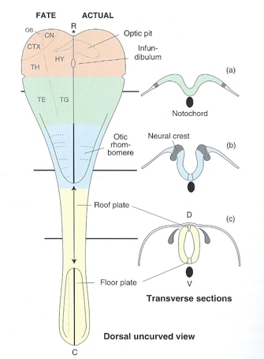

## 4 weeks

[figure not shown]

https://upload.wikimedia.org/wikipedia/commons/4/4c/4_week_embryo_brain.jpg

## ~4 weeks

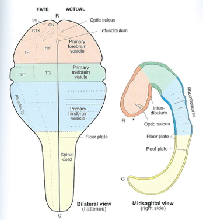

## 6 weeks

[figure not shown]

https://upload.wikimedia.org/wikipedia/commons/thumb/3/33/6_week_human_embryo_nervous_system.svg/500px-6_week_human_embryo_nervous_system.svg.png

## ~6 weeks

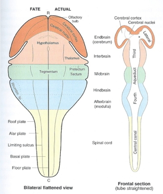

## Beyond

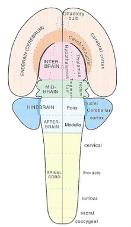

## Organization of the brain

| Major division | Ventricular Landmark | Embryonic Division | Structure |
| --- | --- | --- | --- |
| Forebrain | Lateral | Telencephalon | Cerebral cortex |
|  |  |  | Basal ganglia |
|  |  |  | Hippocampus, amygdala |
|  | Third | Diencephalon | Thalamus |
|  |  |  | Hypothalamus |
| Midbrain | Cerebral Aqueduct | Mesencephalon | Tectum, tegmentum |

## Organization of the brain

| Major division | Ventricular Landmark | Embryonic Division | Structure |
| --- | --- | --- | --- |
| Hindbrain | 4th | Metencephalon | Cerebellum, pons |
|  | – | Mylencephalon | Medulla oblongata |

## References

Gogtay, Nitin, Jay N Giedd, Leslie Lusk, Kiralee M Hayashi, Deanna Greenstein, A Catherine Vaituzis, Tom F Nugent, et al. 2004. “Dynamic Mapping of Human Cortical Development During Childhood Through Early Adulthood.” *Proceedings of the National Academy of Sciences of the United States of America* 101 (21). National Acad Sciences: 8174–79.

Hagmann, P., O. Sporns, N. Madan, L. Cammoun, R. Pienaar, V. J. Wedeen, R. Meuli, J.-P. Thiran, and P. E. Grant. 2010. “White Matter Maturation Reshapes Structural Connectivity in the Late Developing Human Brain.” *Proceedings of the National Academy of Sciences* 107 (44): 19067–72. doi:10.1073/pnas.1009073107.

Hofman, Michel A. 2014. “Evolution of the Human Brain: When Bigger Is Better.” *Frontiers in Neuroanatomy* 8 (March). doi:10.3389/fnana.2014.00015.

Konner, Melvin. 2011. *The Evolution of Childhood*. Belknap Press of Harvard University Press. http://www.hup.harvard.edu/catalog.php?isbn=9780674062016.

Rakic, Pasko. 2009. “Evolution of the Neocortex: A Perspective from Developmental Biology.” *Nature Reviews Neuroscience* 10 (10). Nature Publishing Group: 724–35.